# Time Series Assignment 1

Iker Caballero Bragagnini

2023-04-07

## GDPUSAvar: Gross Domestic Product variation in USA

```r
serie=ts((read.table("gdpUSAvar.dat",header=F)),start=1990,freq=4)
```

#### 1) If we propose an ARMA(2,0) and an ARMA(1,1), the second is a better model

Answer: $FALSE$

To assess whether a model is better than other, we need to carry on the validation of the two models proposed and the computation of model selection measures based on other criteria (explained after). This is because in case one of the models is not valid, then we can be sure that it will not be better than a valid model. We do not include the validation of both models for the sake of brevity (the exercise does not demand them), even though it has been carried on and it is commented.

```r
model_ar2=arima(serie,order=c(2,0,0))
model_arma=arima(serie,order=c(1,0,1))
```

The results of the validation for the first model show how the residuals behave like a white noise and that homoskedasticity (checked through squared residuals), independence of lags (checked through the Ljung-Box statistic) do hold, but normality (checked through normality tests and histograms) does not.

Meanwhile, the results from the validation analysis in the second model are merely the same as with the previous model. All in all, both models seem to be valid, showing homoskedasticity (no volatiliy) and independence of lags, but having some normality problems. These latter problems might be due to a possible outlier, which can be detected at the left of the distribution, so we can think about a series that does not contain that observation. We can also check how all the coefficients are significant at the 5% significance level, which indicates no parameter should be eliminated.

```r
abs(model_ar2$coef/sqrt(diag(model_ar2$var.coef)))
```

```
##       ar1       ar2 intercept
##  3.411880  2.176965  6.549268
```

```r
abs(model_arma$coef/sqrt(diag(model_arma$var.coef)))
```

```
##       ar1       ma1 intercept
##  5.163750  2.168362  6.275043
```

```r
obs=window(serie,start=ultim)
resul=data.frame(
  Sigma2Z=c(model_ar2$sigma2, model_arma$sigma2),
  AIC=c(AIC(model_ar2), AIC(model_arma)),
  BIC=c(BIC(model_ar2), BIC(model_arma)),
  RMSE=c(fRMSE(obs,prar2),fRMSE(obs,prarma)),
  MAE=c(fMAE(obs,prar2),fMAE(obs,prarma)),
  RMSPE=c(fRMSPE(obs,prar2),fRMSPE(obs,prarma)),
  MAPE=c(fMAPE(obs,prar2),fMAPE(obs,prarma)),
  CI_Length=c(fCI(tuar2,tlar2),fCI(tuarma,tlarma)))
row.names(resul)=c("AR(2)","ARMA(1,1)")
resul
```

```
##            Sigma2Z      AIC      BIC      RMSE       MAE     RMSPE      MAPE
## AR(2)     4.483507 528.8251 539.9751 0.6973069 0.5709096 0.4115847 0.2667970
## ARMA(1,1) 4.514371 529.6305 540.7804 0.7021945 0.5763017 0.4088805 0.2673888
##           CI_Length
## AR(2)      8.318700
## ARMA(1,1)  8.314336
```

We finally highlight that, even though we favour the AR(2) model, both are quite similar.

#### 2) The fitted ARMA(1,1) model is stationary and invertible

Answer: $TRUE$

When assesing the stationarity and invertibility of the model, it is necessary to use the polinomical form of the model, which is the following:

$$(1-0.7008B)x_t=(1-0.3789B)w_t$$

To assess stationarity of the model, we can check the roots of the AR polynomial

$$1-0.7008B=0 \rightarrow B=\frac{1}{0.7008}$$
$$\left|\frac{1}{0.7008}\right|>1 \rightarrow Stationarity$$

Because of the absolute value of the root of the AR polynomial is greater than one, we can confirm that the ARMA(1,1) model is stationary.

Now, for the invertibility, we can check the roots of the MA polynomial.

$$1-0.3789B=0 \rightarrow B=-\frac{1}{0.3789}$$
$$\left|-\frac{1}{0.3789}\right|>1 \rightarrow Invertible$$

Because of the absolute value of the root of the MA polynomial is greater than one, we can confirm that the ARMA(1,1) model is stationary and invertible.

## EURODOL: Monthly Average Dolar/Euro exchange

#### 3) Although the mean is seemingly not constant, valid stationary-ARMA models can be fitted to the original series

Answer: $TRUE$

```r
serie=ts((read.table("eurodol.dat")),start=1995,freq=12)
```

In order to see whether this could be the case, we first do some exploratory analysis of the original series to see whether it needs modifications for stationarity and then we estimate different models to see if the possible models that are estimated can be valid and stationary.

Looking at the original series, one can observe that the variance seems to be constant and that there is no seasonal pattern to consider. However, the mean function seems to be more or less constant in the graph, but the ACF indicates that there might be non-stationarity (so the mean is not constant).

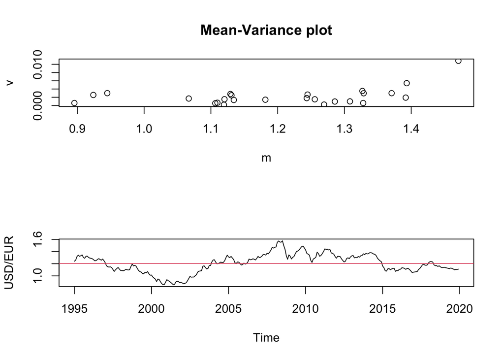

```r
m=apply(matrix(serie,ncol=25),2,mean)
v=apply(matrix(serie,ncol=25),2,var)

par(mfrow=c(2,1))
plot(v~m,main="Mean-Variance plot")
plot(serie, ylab = "USD/EUR")
abline(h=mean(serie),col=2)
```

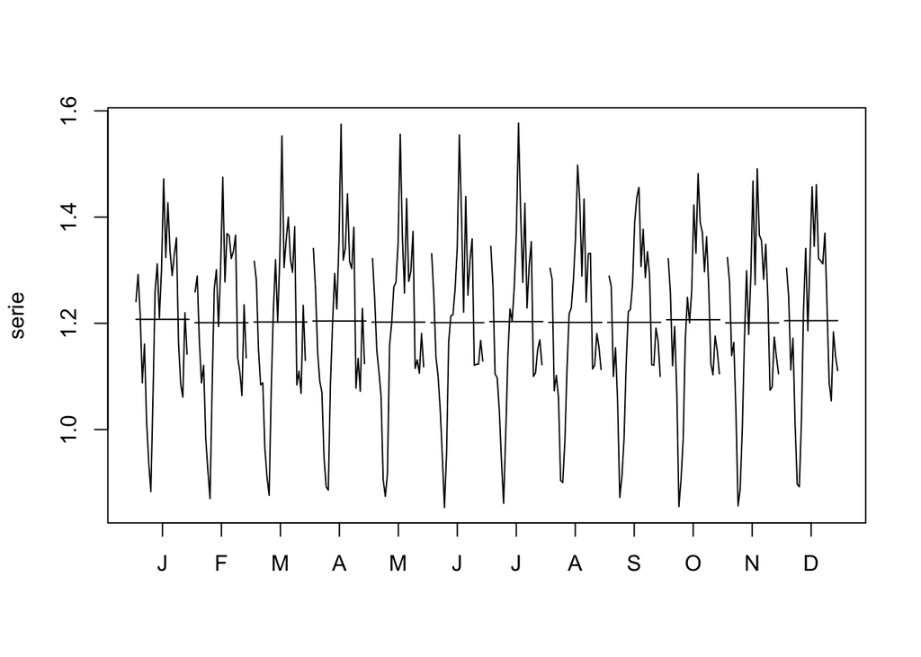

```r
par(mfrow=c(1,1))
monthplot(serie)
```

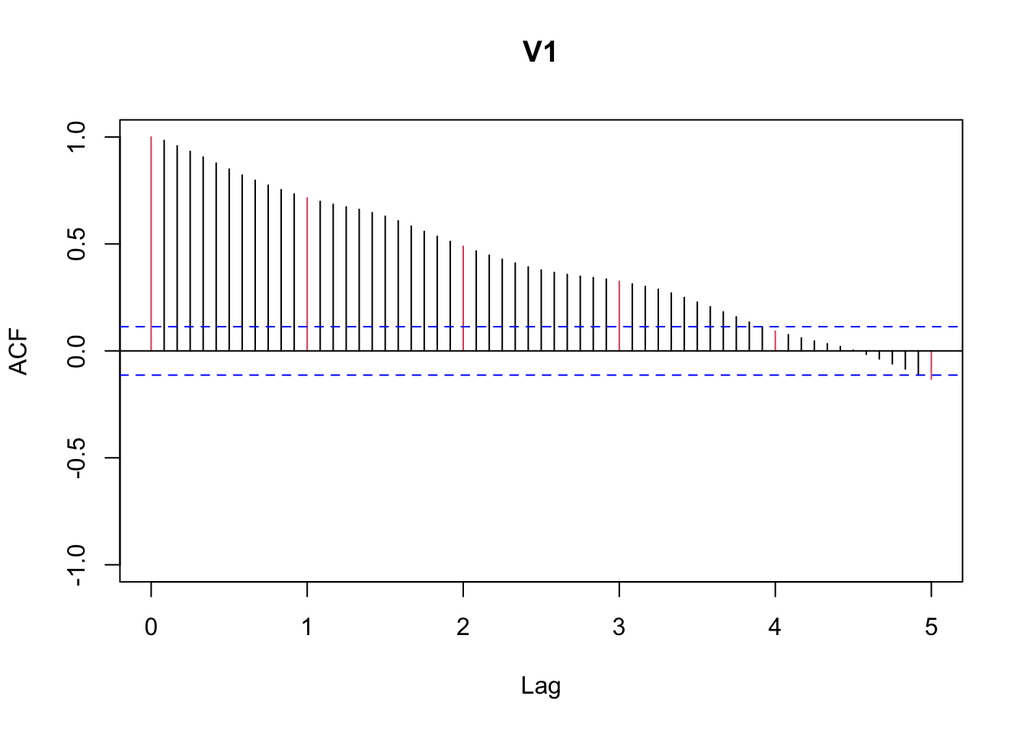

```r
acf(serie,ylim=c(-1,1),lag.max=60,col=c(2,rep(1,11)))
```

Hence, there are two cases: one in which the mean is assumed to be constant and stationary models can be used, and one in which the series is not stationary and one needs to use non-stationary models such as ARIMA models. In fact, the constant assumption seems not too adequate.

We just focus on the first case, so that we can analyze the validity of the models proposed (not considering ARIMA models nor ARMA models with differenciated series). From the ACF and the PACF, we can clearly identify an AR(2) model, which is stationary because all AR models are.

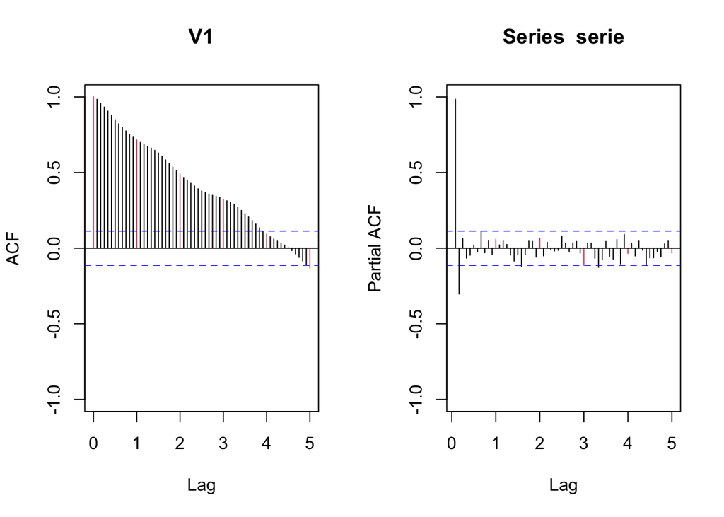

```r
par(mfrow=c(1,2))
acf(serie,ylim=c(-1,1),lag.max=60,col=c(2,rep(1,11)))
pacf(serie,ylim=c(-1,1),lag.max=60,col=c(rep(1,11),2))
```

```r
mod_ar2 <- arima(serie,order=c(2,0,0))
```

## PreuIndEner: Monthly Energy Price in Industry in Spain

```r
serie=ts(read.table("preuIndEner.dat"),start=2000,freq=12)
```

#### 4) This monthly series has a seasonal component and therefore, for the original series, we have to identify a regular and a seasonal part for the model

Answer: $FALSE$

To check the presence of a seasonal component, we should use a monthplot. In this case, we can see that there is a slight increase in the median level starting in May and extending until October, where it begins to decrease.

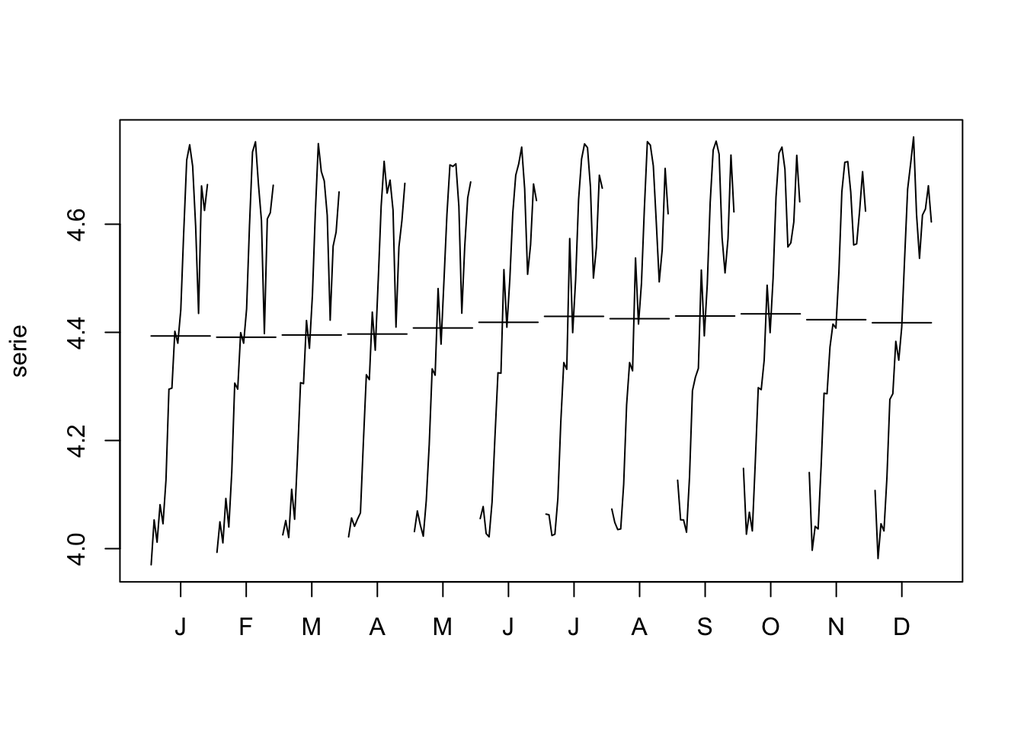

```r
serie=log(serie); monthplot(serie)
```

Nevertheless, the identification step allows as to see that there are no significant seasonal lags, so that we do not need to specify the seasonal part of the ARIMA model (even though it would be necessary if there were significant seasonal lags). We first detect that this series needs one differentiation to obtain stationarity (the ACF and the PACF to detect this are not shown), and then we can obtain the ACF and PACF of the stationary time series to check that this is in fact the situation: no seasonal lag except the very first one is significant.

```r
d1serie=diff(serie);var(d1serie);var(diff(d1serie))
```

```
##              V1
## V1 0.0006293412
```

```
##              V1
## V1 0.0009185575
```

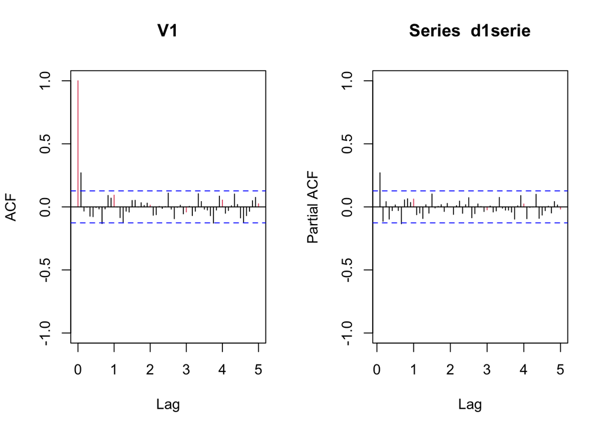

```r
par(mfrow=c(1,2))
acf(d1serie,ylim=c(-1,1),lag.max=60,col=c(2,rep(1,11)))
pacf(d1serie,ylim=c(-1,1),lag.max=60,col=c(rep(1,11),2))
```

## EURIBOR: Euro Interbank Offered Rate

```r
serie=ts((read.table("euribor.dat")),start=1999,freq=12)
```

#### 5) It seems that two regular differentiations are needed to transform the series into a stationary one

Answer: $TRUE$

To assess whether a second differentiation is needed, we transform using a logarithmic transformation (because variance is not constant) and, because there is no clear seasonal pattern, we can proceed checking the stationarity of the time series. One can observe that the series clearly needs a differentiation to obtain stationarity.

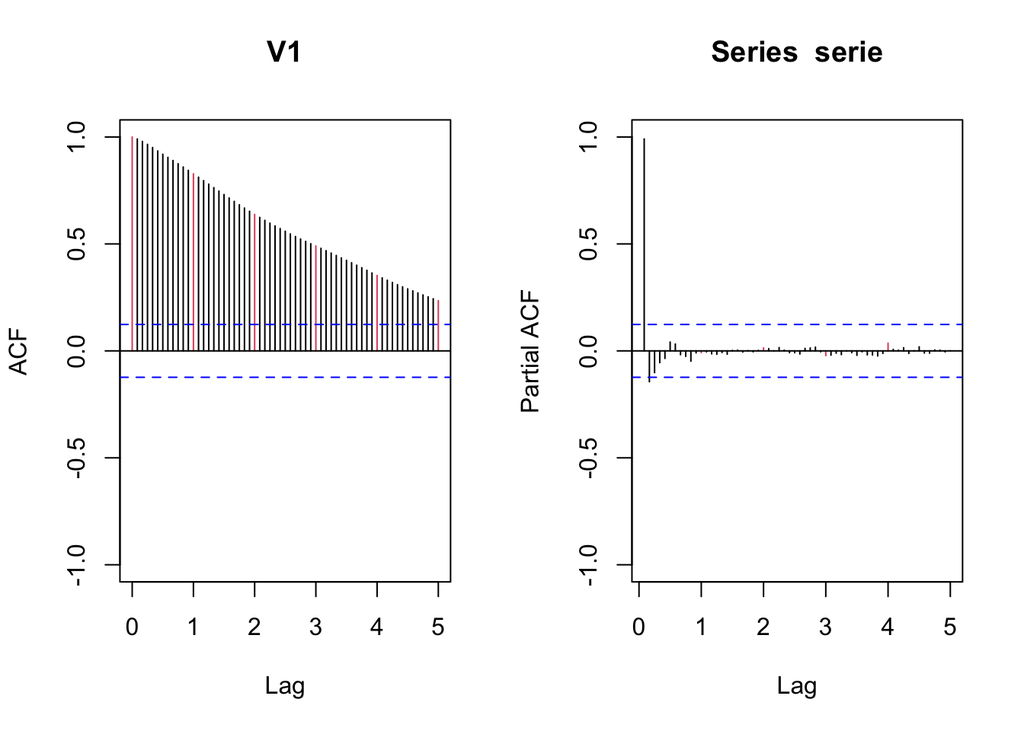

```r
serie=log(serie+1)
par(mfrow=c(1,2))
acf(serie,ylim=c(-1,1),lag.max=60,col=c(2,rep(1,11)))
pacf(serie,ylim=c(-1,1),lag.max=60,col=c(rep(1,11),2))
```

Hence, to know how many differentiations should we use, we differentiate the series iteratively and check the variance at each step. If the variance increases, that means that the previous number of differences is enough. In this case, we can check that the variance decreases until the third difference, where it increases. Hence, we can see that a two differences is enough to transform the series to a stationary series.

```r
var(serie)
```

```
##           V1
## V1 0.4601053
```

```r
d1serie=diff(serie);var(d1serie)
```

```
##             V1
## V1 0.001564921
```

```r
d1d1serie=diff(d1serie);var(d1d1serie)
```

```
##             V1
## V1 0.001006835
```

```r
d1d1d1serie=diff(d1d1serie);var(d1d1d1serie)
```

```
##             V1
## V1 0.002246864
```

#### 6) The once-differenced (d=1) log-transformed-series has a non-significant mean, and thus when fitting an AR(1) process, it is always better to drop this parameter (intercept) from the model

Answer: $TRUE$

To answer this question, we first need to estimate an AR(1) model and see whether the model is significant or not at certain significance levels. Estimating the model, we can see that the intercept is not significant at any common significance level, so this intercept could be eliminated from the model.

```r
mod_ar1=arima(d1serie,order=c(1,0,0))
abs(mod_ar1$coef/sqrt(diag(mod_ar1$var.coef)))
```

```
##       ar1 intercept
## 14.698773  1.180459
```

Given that the expression for this model is $x_t=(1-\phi)\mu+\phi x_{t-1}+w_t$ and the $\phi$ parameter would be significant in this case, the non-significance of this model comes from the mean, and we could obtain a model which does not include this parameter, such as an ARIMA(1,1,0) for the original time series. Hence, it is recommended not to include the intercept for an AR(1) model (it does not give any additional information as it is just a location shift)

#### 7) When fitting an ARIMA(0, 2, 5) to the original series, the residuals are reasonably correct and thus we validate the model

Answer: $FALSE$

In order to determine whether the behaviour of residuals is correct, we can check them through the validation function.

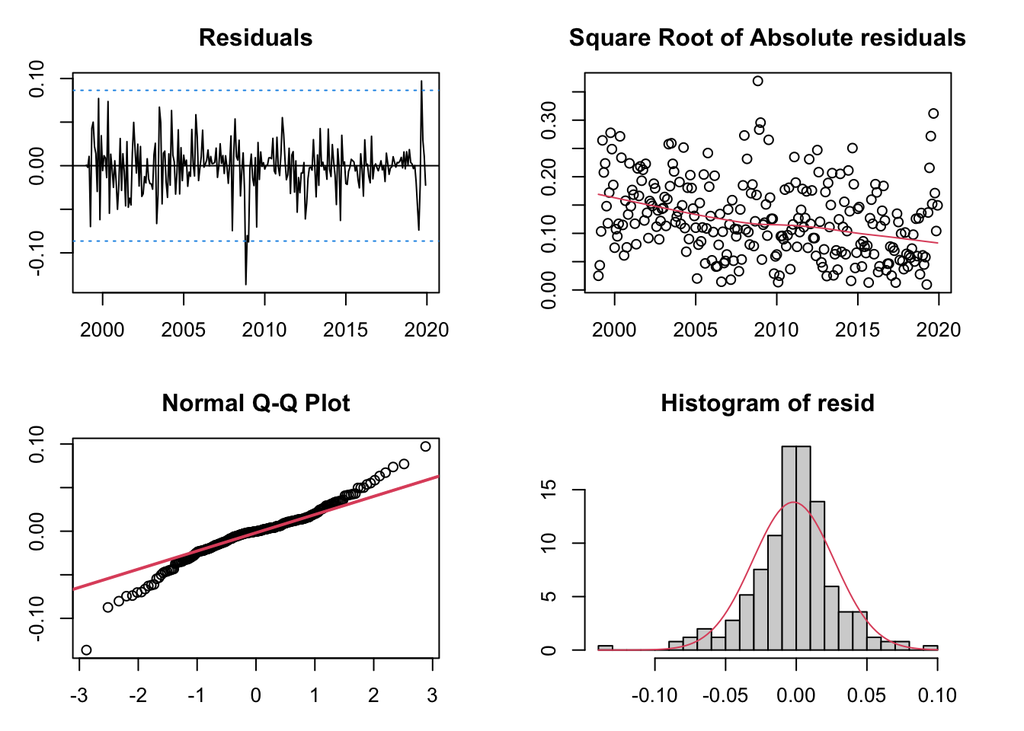

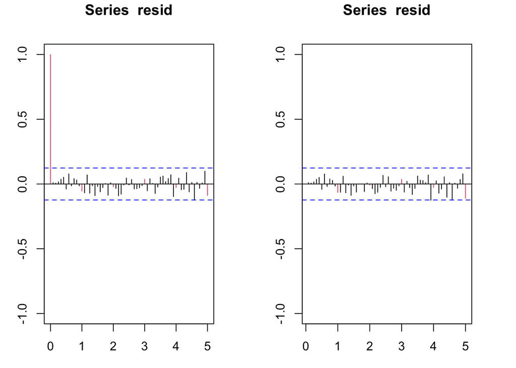

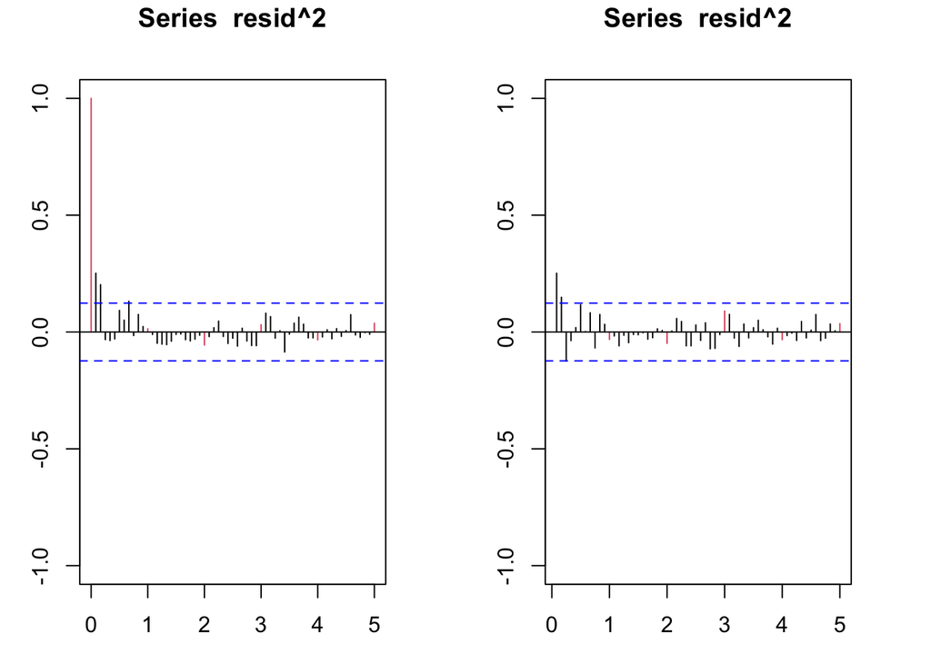

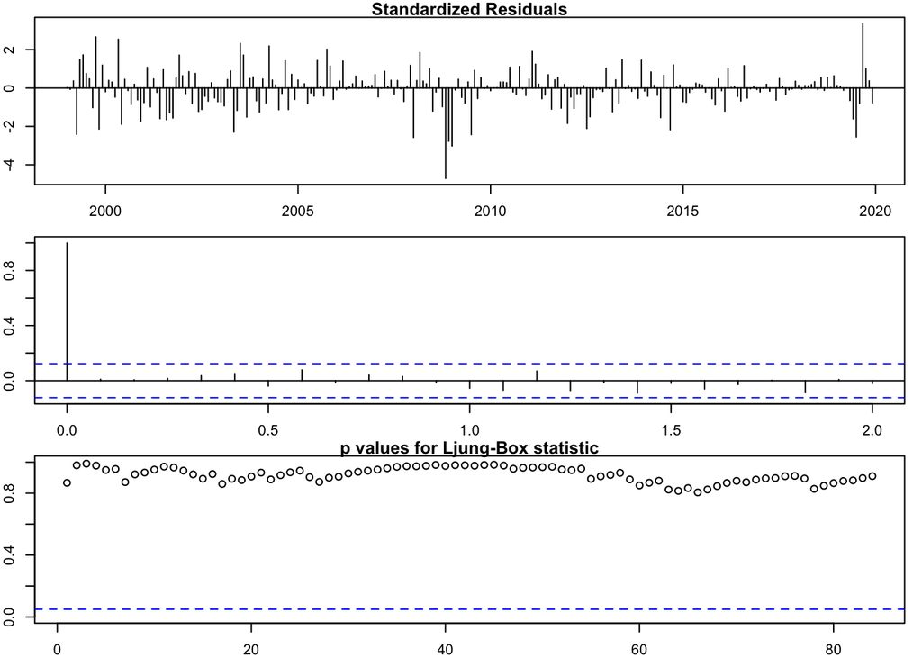

```
##
## --------------------------------------------------------------------
##
## Call:
## arima(x = serie, order = c(0, 2, 5))
##
## Coefficients:
##           ma1      ma2      ma3      ma4      ma5
##       -0.2914  -0.2959  -0.1198  -0.1168  -0.1760
## s.e.   0.0750   0.0722   0.0778   0.0744   0.0664
##
## sigma^2 estimated as 0.0008378:  log likelihood = 528.72,  aic = -1045.45
##
## Modul of AR Characteristic polynomial Roots:
##
## Modul of MA Characteristic polynomial Roots:  1.000033 1.538402 1.538402 1.549302 1.549302
##
## Psi-weights (MA(inf))
##
## --------------------
##      psi 1      psi 2      psi 3      psi 4      psi 5      psi 6      psi 7
## -0.2914161 -0.2958725 -0.1197560 -0.1168451 -0.1760246  0.0000000  0.0000000
##      psi 8      psi 9     psi 10     psi 11     psi 12     psi 13     psi 14
##  0.0000000  0.0000000  0.0000000  0.0000000  0.0000000  0.0000000  0.0000000
##     psi 15     psi 16     psi 17     psi 18     psi 19     psi 20
##  0.0000000  0.0000000  0.0000000  0.0000000  0.0000000  0.0000000
##
## Pi-weights (AR(inf))
##
## --------------------
##       pi 1       pi 2       pi 3       pi 4       pi 5       pi 6       pi 7
## -0.2914161 -0.3807959 -0.3169481 -0.3567747 -0.4534238 -0.3714418 -0.3891889
##       pi 8       pi 9      pi 10      pi 11      pi 12      pi 13      pi 14
## -0.3750936 -0.3847224 -0.3929168 -0.3841084 -0.3865961 -0.3843402 -0.3860164
##      pi 15      pi 16      pi 17      pi 18      pi 19      pi 20
## -0.3865485 -0.3856695 -0.3859458 -0.3856288 -0.3858701 -0.3858706
##
##  Shapiro-Wilk normality test
##
## data:  resid(model)
## W = 0.9605, p-value = 2.121e-06
```

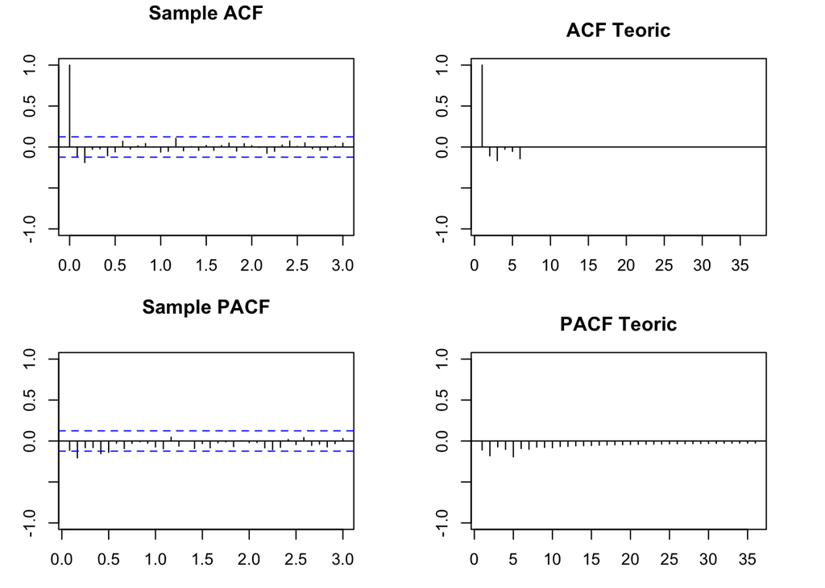

```r
mod_arim25=arima(serie,order=c(0,2,5))
validation(mod_arim25,d1d1serie)
```

In the graphs, one can see that there seems to be some problems with the normality of the residuals, as observations at the extremes do not follow normal distribution tails, and the normality tests reject the normality hypothesis. Even though the a possible outlier preesent in the data is removed, we think that the normality problems would stay the same. When checking for homoskedasticity, we can see that there is no clear presence of volatility, even though there are some significant lags at the beginning, which may indicate the opposite. Finally, we can see that there is independence between lags. Consequently, we cannot say that the model is fully valid as the normality assumption might not hold and there could be volatility.